# HT1

Stefan Quintana, Sofía Escobar, Wilfredo Gallegos

3/22/2022

```
##  [1] "id"                        "budget"
##  [3] "genres"                    "homePage"
##  [5] "productionCompany"         "productionCompanyCountry"
##  [7] "productionCountry"         "revenue"
##  [9] "runtime"                   "video"
## [11] "director"                  "actors"
## [13] "actorsPopularity"          "actorsCharacter"
## [15] "originalTitle"             "title"
## [17] "originalLanguage"          "popularity"
## [19] "releaseDate"               "voteAvg"
## [21] "voteCount"                 "genresAmount"
## [23] "productionCoAmount"        "productionCountriesAmount"
## [25] "actorsAmount"              "castWomenAmount"
## [27] "castMenAmount"
```

```
## 'data.frame':    10000 obs. of  27 variables:
##  $ id                       : int  5 6 11 12 13 14 15 16 18 19 ...
##  $ budget                   : int  4000000 21000000 11000000 94000000 55000000 15000000 839727 12800000 90000000 1300000 ...
##  $ genres                   : chr  "Crime|Comedy" "Action|Thriller|Crime" "Adventure|Action|Science Fiction" "Animation|Family" ...
##  $ homePage                 : chr  "https://www.miramax.com/movie/four-rooms/" NA "http://www.starwars.com/films/star-wars-episode-iv-a-new-hope" "http://movies.disney.com/finding-nemo" ...
##  $ productionCompany        : chr  "Miramax|A Band Apart" "Universal Pictures|Largo Entertainment|JVC" "Lucasfilm|20th Century Fox" "Pixar" ...
##  $ productionCompanyCountry : chr  "US|US" "US|US|JP" "US|US" "US" ...
##  $ productionCountry        : chr  "United States of America" "Japan|United States of America" "United States of America" "United States of America" ...
##  $ revenue                  : num  4.26e+06 1.21e+07 7.75e+08 9.40e+08 6.77e+08 ...
##  $ runtime                  : int  98 110 121 100 142 122 119 141 126 149 ...
##  $ video                    : logi  FALSE FALSE NA NA FALSE FALSE ...
##  $ director                 : chr  "Allison Anders|Alexandre Rockwell|Robert Rodriguez|Quentin Tarantino" "Stephen Hopkins" "George Lucas" "Andrew Stanton" ...
##  $ actors                   : chr  "Tim Roth|Jennifer Beals|Antonio Banderas|Valeria Golino|David Proval|Sammi Davis|Amanda de Cadenet|Madonna|Ione Skye|Lili Taylo "Emilio Estevez|Cuba Gooding Jr.|Denis Leary|Stephen Dorff|Jeremy Piven|Peter Greene|Michael DeLorenzo|Everlast|Michael Wiseman| "FAL…
##  $ actorsPopularity         : chr  "22.225|23.519|17.816|19.893|9.027|7.147|7.769|6.476|7.906|12.838|17.988|20.027|4.47|0.6|1.286|23.95|22.082|3.44"| __truncated__ "9.008|6.383|10.757|18.295|11.772|14.777|9.669|0.98|4.369|0.6|1.38|2.835|3.807|1.4|1.111" "11.881|24.542|14.434|10.651|6.888|5.811|1.…
##  $ actorsCharacter          : chr  "Ted the Bellhop|Angela|Man|Athena|Siegfried|Jezebel|Diana|Elspeth|Eva|Raven|Kiva|Wife|Sarah|Juancho|Corpse|TV Dancing Girl|Ches "Frank Wyatt|Mike Peterson|Fallon|John Wyatt|Ray Cochran|Sykes|Teddy, the Kid|Rhodes|Travis|Dre|Buck|Linda Wyatt|Clarissa|Rita|C "Luk…
##  $ originalTitle            : chr  "Four Rooms" "Judgment Night" "Star Wars" "Finding Nemo" ...
##  $ title                    : chr  "Four Rooms" "Judgment Night" "Star Wars" "Finding Nemo" ...
##  $ originalLanguage         : chr  "en" "en" "en" "en" ...
##  $ popularity               : num  20.9 9.6 100 134.4 58.8 ...
##  $ releaseDate              : chr  "1995-12-09" "1993-10-15" "1977-05-25" "2003-05-30" ...
##  $ voteAvg                  : num  5.7 6.5 8.2 7.8 8.5 8 8 7.9 7.5 8.2 ...
##  $ voteCount                : int  2077 223 16598 15928 22045 9951 4253 1335 8726 1963 ...
##  $ genresAmount             : int  2 3 3 2 3 1 2 2 5 2 ...
##  $ productionCoAmount       : int  2 3 2 1 2 2 2 26 2 1 ...
##  $ productionCountriesAmount: int  1 2 1 1 1 1 1 12 1 1 ...
##  $ actorsAmount             : int  25 15 105 24 76 40 152 29 117 24 ...
##  $ castWomenAmount          : chr  "15" "3" "5" "5" ...
##  $ castMenAmount            : chr  "9" "9" "62" "18" ...
```

## 1) Exploración de datos

```
##        id             budget             genres            homePage
##  Min.   :     5   Min.   :        0   Length:10000       Length:10000
##  1st Qu.: 12286   1st Qu.:        0   Class :character   Class :character
##  Median :152558   Median :   500000   Mode  :character   Mode  :character
##  Mean   :249877   Mean   : 18551632
##  3rd Qu.:452022   3rd Qu.: 20000000
##  Max.   :922260   Max.   :380000000
##  productionCompany  productionCompanyCountry productionCountry
##  Length:10000       Length:10000             Length:10000
##  Class :character   Class :character         Class :character
##  Mode  :character   Mode  :character         Mode  :character
##
##
##
##     revenue             runtime        video           director
##  Min.   :0.000e+00   Min.   :  0.0   Mode :logical   Length:10000
##  1st Qu.:0.000e+00   1st Qu.: 90.0   FALSE:9430      Class :character
##  Median :1.631e+05   Median :100.0   TRUE :84        Mode  :character
##  Mean   :5.674e+07   Mean   :100.3   NA's :486
##  3rd Qu.:4.480e+07   3rd Qu.:113.0
##  Max.   :2.847e+09   Max.   :750.0
##     actors          actorsPopularity   actorsCharacter    originalTitle
##  Length:10000       Length:10000       Length:10000       Length:10000
##  Class :character   Class :character   Class :character   Class :character
##  Mode  :character   Mode  :character   Mode  :character   Mode  :character
##
##
##
##     title           originalLanguage     popularity        releaseDate
##  Length:10000       Length:10000       Min.   :    4.258   Length:10000
##  Class :character   Class :character   1st Qu.:   14.578   Class :character
##  Mode  :character   Mode  :character   Median :   21.906   Mode  :character
##                                        Mean   :   51.394
##                                        3rd Qu.:   40.654
##                                        Max.   :11474.647
##     voteAvg         voteCount      genresAmount    productionCoAmount
##  Min.   : 1.300   Min.   :    1   Min.   : 0.000   Min.   : 0.000
##  1st Qu.: 5.900   1st Qu.:  120   1st Qu.: 2.000   1st Qu.: 2.000
##  Median : 6.500   Median :  415   Median : 3.000   Median : 3.000
##  Mean   : 6.483   Mean   : 1342   Mean   : 2.596   Mean   : 3.171
##  3rd Qu.: 7.200   3rd Qu.: 1316   3rd Qu.: 3.000   3rd Qu.: 4.000
##  Max.   :10.000   Max.   :30788   Max.   :16.000   Max.   :89.000
##  productionCountriesAmount  actorsAmount    castWomenAmount
##  Min.   :  0.000           Min.   :     0   Length:10000
##  1st Qu.:  1.000           1st Qu.:    13   Class :character
##  Median :  1.000           Median :    21   Mode  :character
##  Mean   :  1.751           Mean   :  2148
##  3rd Qu.:  2.000           3rd Qu.:    36
##  Max.   :155.000           Max.   :919590
##  castMenAmount
##  Length:10000
##  Class :character
##  Mode  :character
##
##
##
```

[output not shown]

## 2) Variables cuantitativas y cualitativas

budget -> cuantitativa discreta genres -> cualitativa nominal homePage -> cualitativa nominal productionCompany -> cualitativa nominal productionCompanyCountry -> cualitativa nominal productionCountry -> cualitativa nominal revenue -> cuantitativa discreta runtime -> cuantitativa discreta video -> cualitativa nominal director -> cualitativa nominal actors -> cualitativa nominal actorsPopularity -> cualitativa ordinal actorsCharacter -> cualitativa nominal originalTitle -> cualitativa nominal title -> cualitativa nominal originalLanguage -> cualitativa nominal popularity -> cuantitativa discreta releaseDate -> cualitativa ordinal voteAvg -> cuantitativa discreta voteCount -> cuantitativa discreta genresAmount -> cuantitativa discreta productionCoAomunt -> cuantitativa discreta productionCountriesAmount -> cuantitativa discreta actorsAmount -> cuantitativa discreta castWomenAmount -> cuantitativa discreta castMenAmount -> cuantitativa discreta

## 3) Revisión de normalidad en variables

### budget

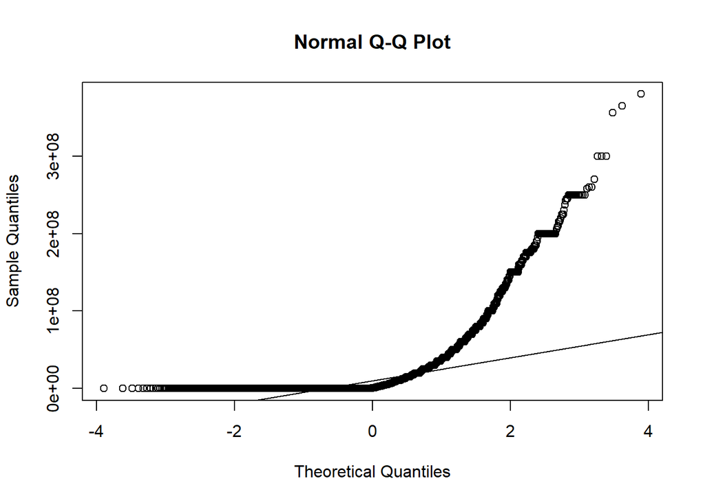

```
##
##  Lilliefors (Kolmogorov-Smirnov) normality test
##
## data:  datos$budget
## D = 0.30625, p-value < 2.2e-16
```

### revenue

[figure not shown]

```
##
##  Lilliefors (Kolmogorov-Smirnov) normality test
##
## data:  datos$revenue
## D = 0.35223, p-value < 2.2e-16
```

Basándose en la gráfica, donde se puede notar que los puntos se alejan de la recta teórica, podemos argumentar que los datos no respetan una distribución normal, lo cuál se confirma en el test Kolmogorov-Smirnov, donde se rechaza la hipótesis nula, por lo tanto, se concluye que los datos no provienen de una distribución normal.

### runtime

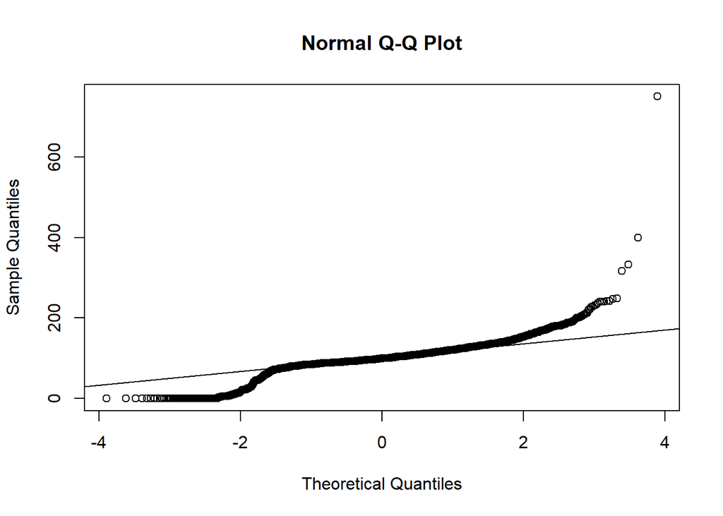

```
##
##  Lilliefors (Kolmogorov-Smirnov) normality test
##
## data:  datos$runtime
## D = 0.14408, p-value < 2.2e-16
```

Análogamente con el set de datos anterior, el valor p del test Kolmogorov-Smirnov hace que se rechace la hipótesis nula y se concluya que los datos no provienen de una distribución normal.

### popularity

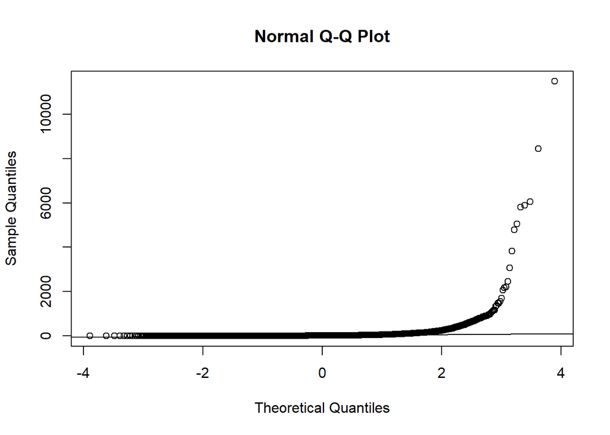

```
##
##  Lilliefors (Kolmogorov-Smirnov) normality test
##
## data:  datos$popularity
## D = 0.41734, p-value < 2.2e-16
```

El valor-p de el test Kolmogorov-Smirnov nos indica que se rechaza la hipótesis nula, por lo tanto, se concluye que los datos no provienen de una distribución normal.

### voteAvg

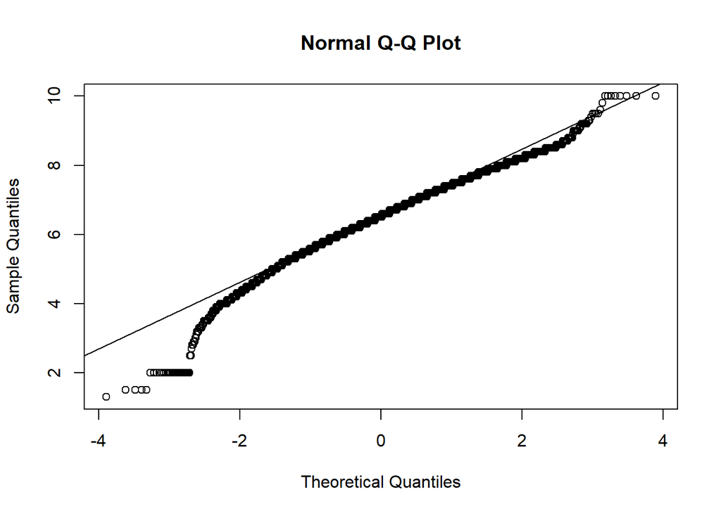

```
##
##  Lilliefors (Kolmogorov-Smirnov) normality test
##
## data:  datos$voteAvg
## D = 0.04591, p-value < 2.2e-16
```

El valor-p de el test Kolmogorov-Smirnov y la gráfica indican que los datos no respetan una distribución normal.

### voteCount

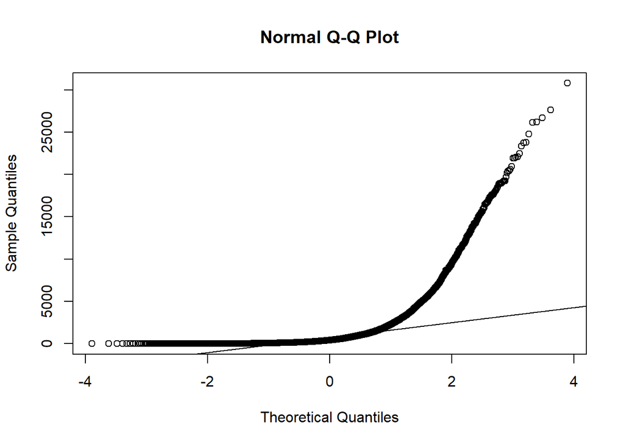

```
##
##  Lilliefors (Kolmogorov-Smirnov) normality test
##
## data:  datos$voteCount
## D = 0.30045, p-value < 2.2e-16
```

Nuevamente, el valor-p del test de Kolmogorov-Smirnov es menor a 0.05, por lo tanto, se rechaza la hipótesis nula y se argumenta que los datos no provienen de una distribución normal.

### genresAmount

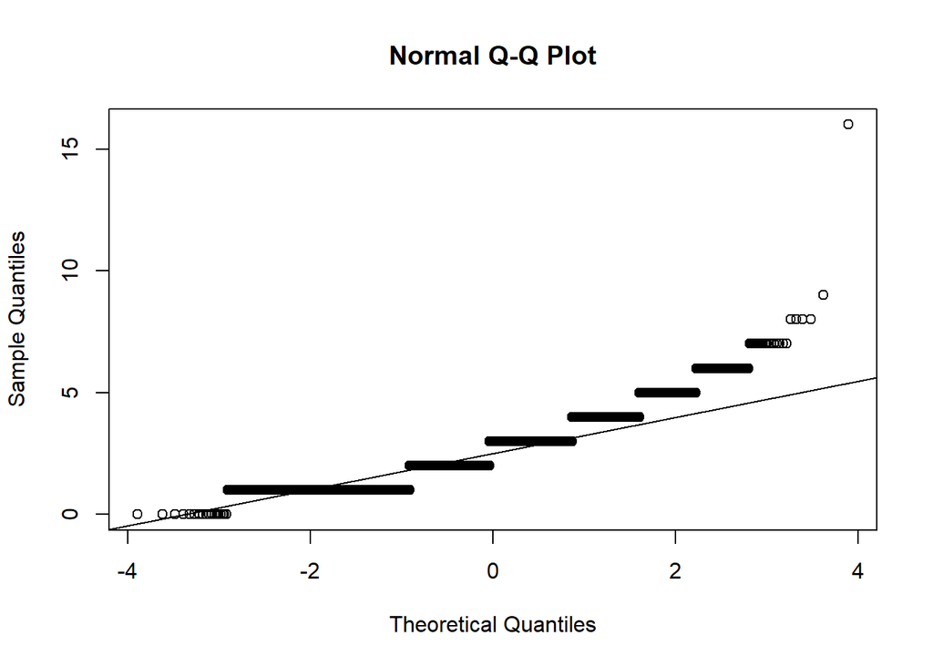

```
##
##  Lilliefors (Kolmogorov-Smirnov) normality test
##
## data:  datos$genresAmount
## D = 0.1836, p-value < 2.2e-16
```

Con un valor-p menor a 0.05 en el test Kolmogorov-Smirnov se rechaza la hipótesis nula y se concluye que los datos no provienen de una distribución normal, argumento que refuerza la gráfica.

### productionCoAomunt

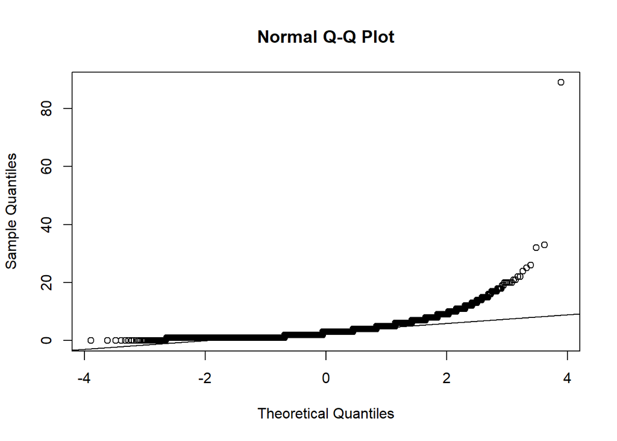

```
##
##  Lilliefors (Kolmogorov-Smirnov) normality test
##
## data:  datos$productionCoAmount
## D = 0.2004, p-value < 2.2e-16
```

El test Kolmogorov-Smirnov revela un valor-p menor a 0.05, además la gráfica nos muestra que los datos no se mantienen cercanos a la recta teórica en su totalidad, por lo tanto, se concluye que los datos no provienen de una distribución normal.

### productionCountriesAmount

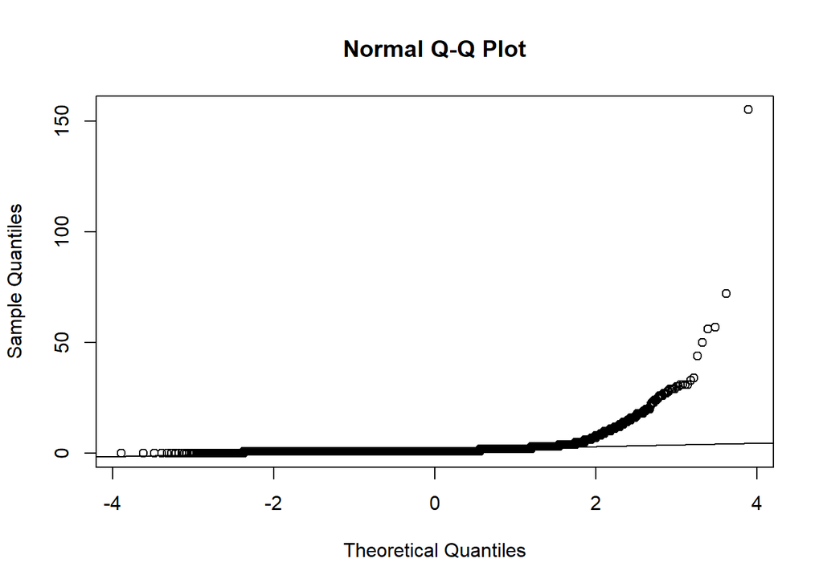

```
##
##  Lilliefors (Kolmogorov-Smirnov) normality test
##
## data:  datos$productionCountriesAmount
## D = 0.39265, p-value < 2.2e-16
```

Al observar la gráfica podemos notar que los datos no se mantienen cercanos a la recta teórica en su totalidad, además el test Kolmogorov-Smirnov nos da un valor-p el cuál nos hace rechazar la hipótesis nula, argumentando así, que los datos no provienen de una distribución normal.

### actorsAmount

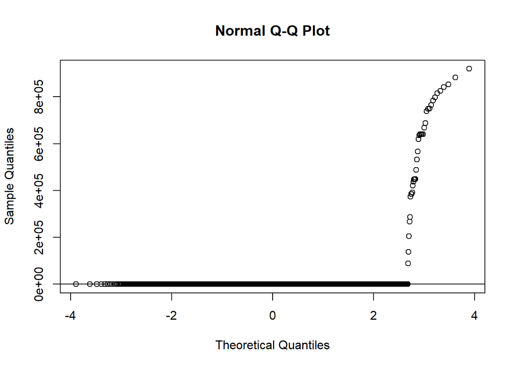

```
##
##  Lilliefors (Kolmogorov-Smirnov) normality test
##
## data:  datos$actorsAmount
## D = 0.51669, p-value < 2.2e-16
```

Debido a que se obtiene un valor-p menor a 0.05 en el test de Kolmogorov-Smirnov, se rechaza la hipótesis nula y se concluye que los datos no provienen de una distribución normal.

### castWomenAmount

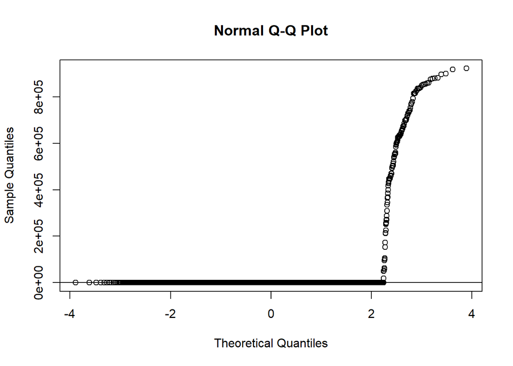

```
##
##  Lilliefors (Kolmogorov-Smirnov) normality test
##
## data:  d1
## D = 0.52831, p-value < 2.2e-16
```

Se puede notar en la gráfica que muchos de los datos no se mantienen en cercanía a la recta teórica, por lo tanto, se concluye que el set de datos no respeta una distribución normal, conclusión reforzada por el test Kolmogorov-Smirnov.

### castMenAmount

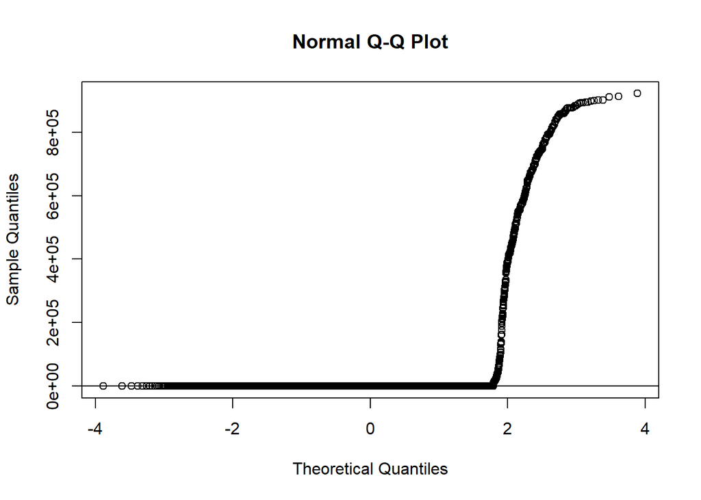

```
##
##  Lilliefors (Kolmogorov-Smirnov) normality test
##
## data:  d2
## D = 0.52814, p-value < 2.2e-16
```

Nuevamente, obtenemos una gráfica donde los valores no se mantienen cercanos a la recta teórica y un valor-p menor a 0.05 en el test Kolmogorov-Smirnov, lo cuál hace que se concluya que no hay normalidad en el set de datos.

## 4.1) ¿Cuáles son las 10 películas que contaron con más presupuesto?

```
##  [1] "Pirates of the Caribbean: On Stranger Tides"
##  [2] "Avengers: Age of Ultron"
##  [3] "Avengers: Endgame"
##  [4] "Pirates of the Caribbean: At World's End"
##  [5] "Justice League"
##  [6] "Avengers: Infinity War"
##  [7] "Superman Returns"
##  [8] "Tangled"
##  [9] "The Lion King"
## [10] "Spider-Man 3"
```

1. Pirates of the Caribbean: On Stranger Tides
2. Avengers: Age of Ultron
3. Avengers: Endgame
4. Pirates of the Caribbean: At World’s End
5. Justice League
6. Avengers: Infinity War
7. Superman Returns
8. Tangled
9. The Lion King
10. Spider-Man 3

## 4.2) ¿Cuáles son las 10 películas que más ingresos tuvieron?

```
##  [1] "Avatar"                       "Avengers: Endgame"
##  [3] "Titanic"                      "Star Wars: The Force Awakens"
##  [5] "Avengers: Infinity War"       "Jurassic World"
##  [7] "The Lion King"                "Spider-Man: No Way Home"
##  [9] "The Avengers"                 "Furious 7"
```

1. Avatar
2. Avengers: Endgame
3. Titanic
4. Star Wars: The Force Awakens
5. Avengers: Infinity War
6. Jurassic World
7. The Lion King
8. Spider-Man: No Way Home
9. The Avengers
10. Furious 7

## 4.3) ¿Cuál es la película que más votos tuvo?

```
##  [1] "Inception"               "Interstellar"
##  [3] "The Dark Knight"         "The Avengers"
##  [5] "Deadpool"                "Avatar"
##  [7] "Guardians of the Galaxy" "Avengers: Infinity War"
##  [9] "Fight Club"              "Pulp Fiction"
```

1. Inception
2. Interestellar
3. The Dark Knight
4. The Avengers
5. Deadpool
6. Avatar
7. Guardians of the Galaxy
8. Avengers: Infinity War
9. Fight Club
10. Pulp Fiction

## 4.4) ¿Cuál es la peor película de acuerdo a los votos de todos los usuarios?

```r
df4 <- datos[order(datos$voteCount, decreasing = FALSE),]
df4$title[1:10]
```

```
##  [1] "La Mera Reyna del Sur"
##  [2] "Star Driver the Movie"
##  [3] "The Next Mega Tsunami"
##  [4] "Three Preludes for Solo Piano By Adam Sherkin"
##  [5] "Mom's Friend 2"
##  [6] "El silencio"
##  [7] "극장판 레이디버그: 미라클 스톤의 비밀"
##  [8] "Thor: Hammer Time"
##  [9] "Sing Along"
## [10] "Tar Pits Film"
```

1. “La Mera Reyna del Sur”
2. “Star Driver the Movie”
3. “The Next Mega Tsunami”
4. “Three Preludes for Solo Piano By Adam Sherkin”
5. “Mom’s Friend 2”
6. “El silencio”
7. “극장판 레이디버그: 미라클 스톤의 비밀”
8. “Thor: Hammer Time”
9. “Sing Along”
10. “Tar Pits Film”

## 4.5) ¿Cuántas películas se hicieron en cada año? ¿En qué año se hicieron más películas? Haga un gráfico de barras

```r
#se separararon las fechas por medio del formar, año, mes y dia, y se utilizao solo el
datos$releaseYear <- as.POSIXct(datos$releaseDate, format ="%Y-%m-%d")
datos$releaseYear <-format(datos$releaseYear, format = "%Y")
datos$releaseYear <-as.integer(datos$releaseYear, format ="%Y")
#se agruparon los datos dependiendo del año en el que se estaba trabajando
df5 <- datos %>% group_by(datos$releaseYear) %>% summarise(freq=n()) %>% ungroup()
print(as_tibble(df5), n = 120)
```

```
## # A tibble: 99 × 2
##    `datos$releaseYear`  freq
##                  <int> <int>
##  1                1902     1
##  2                1920     1
##  3                1921     1
##  4                1922     1
##  5                1925     2
##  6                1926     1
##  7                1927     2
##  8                1929     1
##  9                1930     1
## 10                1931     4
## 11                1932     1
## 12                1933     1
```

[output cut: 87 more lines]

```r
# Creamos un grafico de frecuencias en donde se dividia la cantidad de peliculas por año
df5 %>% slice_max(freq)
```

```
## # A tibble: 1 × 2
##   `datos$releaseYear`  freq
##                 <int> <int>
## 1                2021   816
```

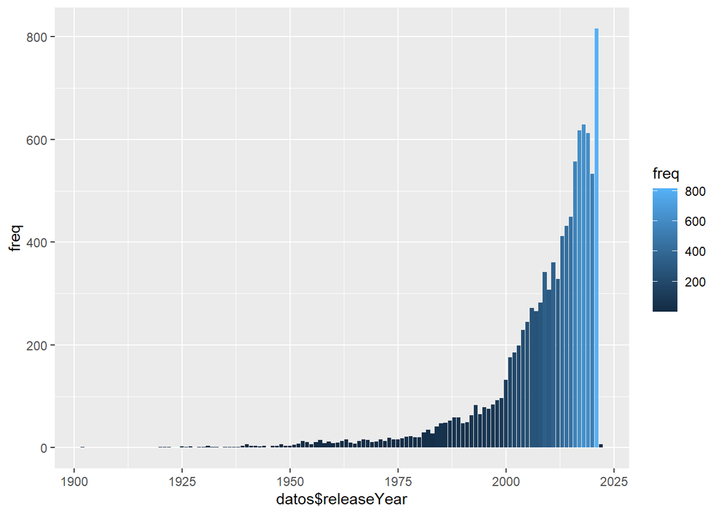

```r
ggplot(df5, aes(x=`datos$releaseYear`, y= freq, fill= freq)) + geom_bar(stat = "identity")
```

El año con más peliculas fue el 2021 con 816 peliculas.

## 4.6) ¿Cuál es el género principal de las 20 películas más recientes? ¿Cuál es el género principal que predomina en el conjunto de datos? Represéntelo usando un gráfico

```r
#20 MAS RECIENTE
#GENERAL
#primero se seleccionan las variables de las que van a depender nuestros datos
dfre <- separate_rows(datos,popularity, title, releaseYear,genres,sep="\\|") %>%
  group_by(title, genres, releaseYear) %>% summarize( popularidad = sum(popularity))
#ordenamos los datos de mayor a menor
dfre1 <- dfre[order(dfre$popularidad, dfre$releaseYear, decreasing = TRUE),]
head(dfre1, 20)
```

```
## # A tibble: 20 × 4
## # Groups:   title, genres [20]
##    title                                  genres          releaseYear populari…¹
##    <chr>                                  <chr>                 <int>      <dbl>
##  1 Eternals                               Action                 2021     11475.
##  2 Eternals                               Adventure              2021     11475.
##  3 Eternals                               Fantasy                2021     11475.
##  4 Eternals                               Science Fiction        2021     11475.
##  5 Spider-Man: No Way Home                Action                 2021      8444.
##  6 Spider-Man: No Way Home                Adventure              2021      8444.
##  7 Spider-Man: No Way Home                Science Fiction        2021      8444.
##  8 Sing 2                                 Animation              2021      6056.
##  9 Sing 2                                 Comedy                 2021      6056.
## 10 Sing 2                                 Family                 2021      6056.
## 11 Sing 2                                 Music                  2021      6056.
## 12 Resident Evil: Welcome to Raccoon City Action                 2021      5887.
## 13 Resident Evil: Welcome to Raccoon City Horror                 2021      5887.
## 14 Resident Evil: Welcome to Raccoon City Science Fiction        2021      5887.
## 15 Encanto                                Animation              2021      5804.
## 16 Encanto                                Comedy                 2021      5804.
## 17 Encanto                                Family                 2021      5804.
## 18 Encanto                                Fantasy                2021      5804.
## 19 Ghostbusters: Afterlife                Adventure              2021      5051.
## 20 Ghostbusters: Afterlife                Comedy                 2021      5051.
## # … with abbreviated variable name ¹popularidad
```

```r
#GENERAL
#primero se seleccionan las variables de las que van a depender nuestros datos
df6 <- separate_rows(datos,popularity, title, releaseYear,genres,sep="\\|") %>%
  group_by(genres) %>% summarize( popularidad = sum(popularity))
#ordenamos los datos de mayor a menor
df66 <- df6[order(df6$popularidad, decreasing = TRUE),]
df66
```

```
## # A tibble: 20 × 2
##    genres            popularidad
##    <chr>                   <dbl>
##  1 "Action"              193852.
##  2 "Comedy"              146286.
##  3 "Adventure"           146270.
##  4 "Drama"               131723.
##  5 "Thriller"            127869.
##  6 "Fantasy"             106226.
##  7 "Science Fiction"     105796.
##  8 "Animation"           102400.
##  9 "Family"               87906.
## 10 "Horror"               79141.
## 11 "Crime"                53864.
## 12 "Romance"              46915.
## 13 "Mystery"              33111.
## 14 "Music"                15367.
## 15 "History"              14261.
## 16 "War"                   9821.
## 17 "TV Movie"              9517.
## 18 "Documentary"           9180.
## 19 "Western"               4840.
## 20 ""                      1592.
```

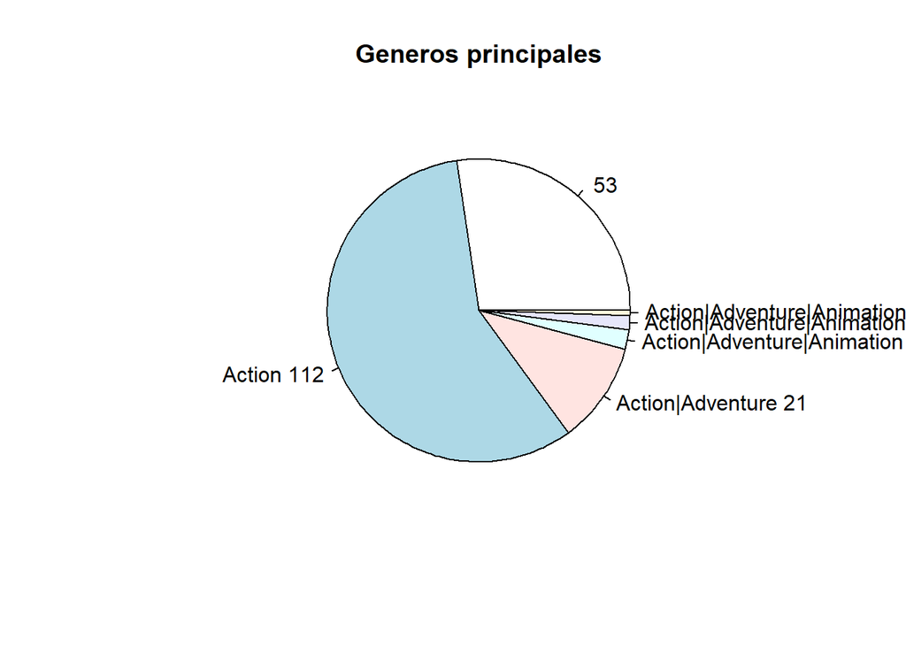

```r
#tabla para poder hacer grafico
generos <- head(table(datos$genres))
lbls <- paste(names(generos), generos)
pie(generos, labels = lbls,
   main="Generos principales")
```

El genero que predomina en el conjunto de datos es el de acción, mientras que el que predomina en las 20 es de igual manera es Accion.

## 4.7) ¿Las películas de qué genero principal obtuvieron mayores ganancias?

```r
#primero se seleccionan las variables de las que van a depender nuestros datos
df7 <- separate_rows(datos,genres,sep="\\|") %>%
  group_by(genres) %>% summarize( ganancias = sum(revenue) - sum(budget),)#planteamos una funcion que nos de las ganancias
#ordenamos los datos de mayor a menor
df77 <- df7[order(df7$ganancias, decreasing = TRUE),]
head(df77, 20)
```

```
## # A tibble: 20 × 2
##    genres               ganancias
##    <chr>                    <dbl>
##  1 "Adventure"       176725695776
##  2 "Action"          161542982770
##  3 "Comedy"          123220595613
##  4 "Drama"           108383019135
##  5 "Fantasy"          89682965126
##  6 "Family"           82925924710
##  7 "Science Fiction"  82438706304
##  8 "Thriller"         79518128443
##  9 "Animation"        62748904908
## 10 "Romance"          51895793837
## 11 "Crime"            37755278024
## 12 "Horror"           25360625694
## 13 "Mystery"          24303678161
## 14 "War"              11981015225
## 15 "History"          11310244013
## 16 "Music"             9381401876
## 17 "Western"           2787642773
## 18 "Documentary"       1000606729
## 19 ""                   258725845
## 20 "TV Movie"          -223847530
```

Las peliculas del genero de Aventura son las que más gancias tienen, incluso si en el inciso pasado vimos que el genero que predominaba era el de Accion.

## 4.8) ¿La cantidad de actores influye en los ingresos de las películas?¿se han hecho películas con más actores en los últimos años?

```r
#obtenemos la correlacion de spearman para saber si la cantidad de autores influye en el ingreso
cor(x = datos$actorsAmount, y = datos$revenue, method = "spearman")
```

```
## [1] 0.5561046
```

```r
#hacemos una tabla para ver si hay mas
df8 <- separate_rows(datos,releaseYear,actorsAmount) %>%
  group_by(releaseYear) %>% summarize( Actores = sum(actorsAmount))
df8 <- df8[order(df8$releaseYear, decreasing = TRUE),]
df8
```

```
## # A tibble: 99 × 2
##    releaseYear Actores
##          <int>   <int>
##  1        2022      85
##  2        2021 2601837
##  3        2020 1509624
##  4        2019 1290019
##  5        2018 2451055
##  6        2017 2220481
##  7        2016 2290345
##  8        2015  631392
##  9        2014  947559
## 10        2013  770668
## # … with 89 more rows
```

## 4.9) ¿Es posible que la cantidad de hombres y mujeres en el reparto influya en la popularidad y los ingresos de las películas?

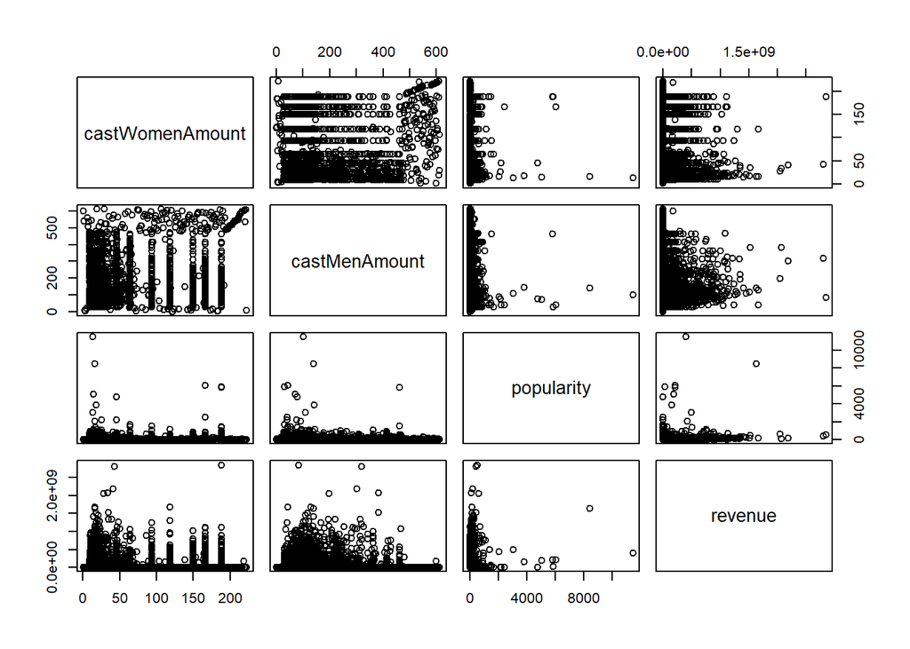

```r
#planteamos un grafico de correlacion para asi poder observar su las variables se encuentran relacionadas entre ellas y así poder determinar si influyen unas con otras

plot(datos[,c("castWomenAmount","castMenAmount","popularity","revenue")])
```

De acuerdo al gráfico realizado se determinó que existe una correlación leve entre ganancias (revenue) y popularidad. Mientras que, no hay una correlación evidente entre las demás variables.

## 4.10) ¿Quiénes son los directores que hicieron las 20 películas mejor calificadas?

```r
library(tidyr)
df10 <- datos[order(datos$voteAvg, decreasing = TRUE),]
df <- data.frame(director=df10$director[1:20],
                 calificacion=df10$voteAvg[1:20],
                 titulo=df10$title)
df2<-df[df$director!="",]
head(df2,20)
```

```
##                                                                                       director
## 1                                                                                 Thomas Coven
## 2                                                                V\xedctor Barba|Juan Olivares
## 3                                                                                Rebecca Sugar
## 4                                                                            Laurent Bouzereau
## 5                                                                                 Kaku Arakawa
## 6                                                                               Christin Baker
## 8                                                                          Miguel Angel Zavala
## 10                                                      Dave Bullock|Troy Adomitis|Victor Cook
## 11                                                                                Samuel Leong
## 14                                                                              Won Myeong-jun
## 15                                                                          Selena Quintanilla
## 16                                                                              Haruo Sotozaki
## 17                                                                              Haruo Sotozaki
## 19                                                                             Ulises Valencia
```

[output cut: 27 more lines]

## 4.11) ¿Cómo se correlacionan los presupuestos con los ingresos? ¿Los altos presupuestos significan altos ingresos? Haga los gráficos que necesite, histograma, diagrama de dispersión

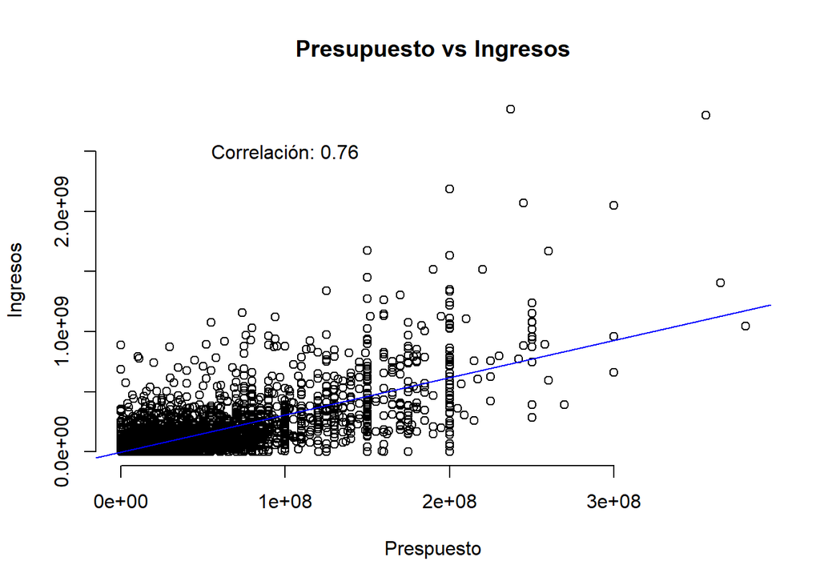

```r
plot(datos$budget, datos$revenue, main = "Presupuesto vs Ingresos",
     xlab = "Prespuesto", ylab = "Ingresos",
     pch = 21, frame = FALSE)
abline(lm(datos$revenue ~ datos$budget, data = datos), col = "blue")
text(paste("Correlación:", round(cor(datos$budget, datos$revenue), 2)), x = 1e+08, y =2.5e+09)
```

```r
correlation <- lm(datos$budget~datos$revenue)
summary(correlation)
```

```
##
## Call:
## lm.default(formula = datos$budget ~ datos$revenue)
##
## Residuals:
##        Min         1Q     Median         3Q        Max
## -299096514   -8028666   -8028666    1971334  191971334
##
## Coefficients:
##                Estimate Std. Error t value Pr(>|t|)
## (Intercept)   8.029e+06  2.558e+05   31.39   <2e-16 ***
## datos$revenue 1.855e-01  1.599e-03  116.00   <2e-16 ***
## ---
## Signif. codes:  0 '***' 0.001 '**' 0.01 '*' 0.05 '.' 0.1 ' ' 1
##
## Residual standard error: 23910000 on 9998 degrees of freedom
## Multiple R-squared:  0.5737, Adjusted R-squared:  0.5737
## F-statistic: 1.346e+04 on 1 and 9998 DF,  p-value: < 2.2e-16
```

## 4.12) ¿Se asocian ciertos meses de lanzamiento con mejores ingresos?

A partir del gráfico de barras presentado podemos obesrvar que los meses con mejores ingresos son junio, diciembre y julio como tercer lugar.

```r
datos$releaseDate <- as.Date(datos$releaseDate)
meses <- setNames(aggregate(datos$revenue, by=list(datos$releaseDate), FUN=sum),c("Fecha","Cantidad"))
meses$mes<-months(as.Date(meses$Fecha,format="%m/%d/%y"))
meses <- setNames(aggregate(meses$Cantidad, by=list(meses$mes), FUN=sum),c("mes","Cantidad"))

meses
```

```
##           mes    Cantidad
## 1       abril 36606574887
## 2      agosto 32840682550
## 3   diciembre 69525553232
## 4       enero 22020446418
## 5     febrero 30293297435
## 6       julio 61735301475
## 7       junio 77597881637
## 8       marzo 41659492701
## 9        mayo 61316118519
## 10  noviembre 57694134749
## 11    octubre 41638470602
## 12 septiembre 34451301833
```

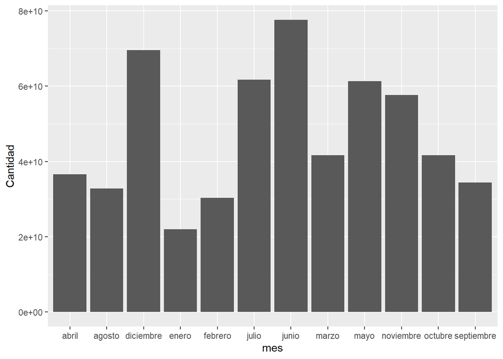

```r
ggplot(meses, aes(x = mes, y = Cantidad)) +
  geom_bar(stat = "identity")
```

```r
str(datos$releaseDate)
```

```
##  Date[1:10000], format: "1995-12-09" "1993-10-15" "1977-05-25" "2003-05-30" "1994-07-06" ...
```

## 4.13) ¿En qué meses se han visto los lanzamientos con mejores ingresos?¿cuantas películas, en promedio, se han lanzado por mes?

A partir del siguiente analisis podemos observar qe la pelicula con mas ingresos(Avatar) fue lanzada en el mes de diciembre, la segunda con mejores ganancias(Avengers: Endgame) fue lanzada en abril y la tercera con mas ingresos(Titanic) fue lanzada en noviembre. Si se desea conocer los meses de las siguientes con mas ganancias se puede consultar la siguiente tabla.

```r
library(lubridate)
df13 <- datos[order(datos$revenue, decreasing = TRUE),]
df <- data.frame(title=df13$title[1:5],
                 revenue=df13$revenue[1:5],
                 releaseDate=df13$releaseDate[1:5])
df$releaseDate <- as.Date(df$releaseDate)
meses13 <- setNames(aggregate(df$revenue, by=list(df$releaseDate), FUN=sum),c("Fecha","Cantidad"))
meses13$mes<-months(as.Date(meses13$Fecha,format="%m/%d/%y"))
meses13 <- setNames(aggregate(meses13$Cantidad, by=list(meses13$mes), FUN=sum),c("mes","Cantidad"))
meses13
```

```
##         mes   Cantidad
## 1     abril 4844040201
## 2 diciembre 4915469827
## 3 noviembre 2187463944
```

```r
lanzamientos <- months(as.POSIXlt(datos$releaseDate, format="%m/%d/%Y"))
table(lanzamientos)
```

```
## lanzamientos
##      abril     agosto  diciembre      enero    febrero      julio      junio
##        696        913        935        652        706        812        819
##      marzo       mayo  noviembre    octubre septiembre
##        815        698        807       1068       1079
```

```r
z<-nrow(datos)/12
print(paste("promedio de peliculas producidas por mes: ",round(z,2)))
```

```
## [1] "promedio de peliculas producidas por mes:  833.33"
```

#### ¿cuantas películas, en promedio, se han lanzado por mes?

En total fueron lanzadas 10,000 peliculas, por lo que las cantidad de peliculas lanzadas por mes es de alrededor de 833.

## 4.14) ¿Cómo se correlacionan las calificaciones con el éxito comercial?

Se puede observar en el diagrama de dispesion siguiente que no existe ninguna correlacion entre la popularidad de las peliculas con su exito comercial(ingresos). Una correlacion de 0.16 de estos datos nos afirman lo establecido anteriormente.

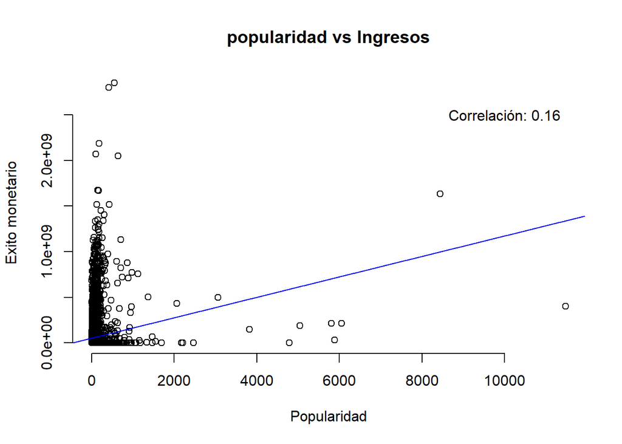

```r
plot(datos$popularity, datos$revenue, main = "popularidad vs Ingresos",
     xlab = "Popularidad", ylab = "Exito monetario",
     pch = 21, frame = FALSE)
abline(lm(datos$revenue ~ datos$popularity, data = datos), col = "blue")
text(paste("Correlación:", round(cor(datos$popularity, datos$revenue), 2)), x = 10000, y =2.5e+09)
```

```r
correlation <- lm(datos$revenue~datos$popularity)
#summary(correlation)

#library("ggpubr")
#ggscatter(datos, x = "popularity", y = "revenue",
#          add = "reg.line", add.params =  list(color="red"),
#          conf.int = TRUE, cor.coef = TRUE, cor.method = "pearson",
#          xlab = "calificación", ylab = "éxito comercial",
#          color = "dark grey", shape = 19,
#          title = "Correlacion entre calificaciones y el éxito comercial")
```

## 4.15) ¿A qué género principal pertenecen las películas más largas?

De las 5 peliculas mas largas, 3 de estas tienen como genero principal el *Drama*, y las otras dos tienen como genero *Documental*. Es importante recalcar que a pesar de que son mas de drama, las primeras dos mas largas son de documental, y las posiciones 3-5 son de drama.

```r
df15 <- datos[order(datos$runtime, decreasing = TRUE),]
df <- data.frame(title=df15$title[1:5],
                 genre=df15$genres[1:5],
                 runtime=df15$runtime[1:5])
df
```

```
##                                                            title
## 1          How Ponyo was Born ~Hayao Miyazaki's Thought Process~
## 2 Crystal Lake Memories: The Complete History of Friday the 13th
## 3                                                       Napoleon
## 4                                                           1900
## 5                                                      Cleopatra
##                   genre runtime
## 1           Documentary     750
## 2           Documentary     400
## 3     Drama|History|War     333
## 4         Drama|History     317
## 5 Drama|History|Romance     248
```